# New York Bail Reform and Pretrial Detention Outcomes

Author

Hodan Aden and Amel Osman

## Introduction and Motivation

Imagine getting arrested on a nonviolent charge and, because you can’t afford bail, sitting in jail for weeks before your case is even resolved. Does that detention itself change whether you end up convicted, separate from the facts of the case against you? That question sits at the center of one of the most contested criminal justice policies in the country. New York’s 2020 bail reform law is now six years old and is still cited by both supporters and critics as evidence for their side.

This project looks at three related questions using 1.24 million New York State case records from 2019 through 2024. Does pretrial detention predict conviction outcomes, independent of the underlying charge? Does that relationship change depending on a county’s poverty rate? And did New York’s 2020 reform actually change the relationship between detention and conviction?

These aren’t just academic questions. Pretrial detention can cost someone their job, their housing, or custody of their kids, all before they’ve been convicted of anything. County courts deciding how to allocate bail resources, state legislators trying to figure out if reform is working, and other states considering similar laws are all potential audiences for what this data shows.

A quick note on vocabulary for anyone new to this area: “pretrial detention” means being held in jail after arrest but before trial, usually because bail couldn’t be paid or was denied outright. “Conviction” here covers any case that resolved in a guilty finding or plea, as opposed to dismissal or acquittal. New York’s 2020 reform eliminated cash bail for most misdemeanors and non-violent felonies, so a lot of defendants who would have been held pretrial before 2020 are now released while their case proceeds.

## Background and Related Work

Two existing studies shaped how we approached this. Dobbie and Yang (2021) did a county-level study over ten years and found that counties with more pretrial detention also had higher poverty and lower employment, and the effects carried into the next generation, kids born in high-detention counties earned less decades later. That’s part of why we treated county poverty rate as a variable worth studying on its own, not just something to control for.

From a different angle, Dobbie, Goldin, and Yang (2018) used random judge assignment to isolate detention’s actual effect and found it does raise the probability of conviction, mostly through an increase in guilty pleas. That paper is the closest precedent to what we’re doing here, but it doesn’t look at New York specifically, doesn’t cover the 2020 reform, and doesn’t break things down by county poverty. That combination, New York, the 2020 reform, and county-level economic context together, is the gap we’re filling.

## Data Engineering

New York’s Division of Criminal Justice Services (DCJS) and Office of Court Administration (OCA) publicly release the Supplemental Pretrial Release Data File, a reporting requirement created by the 2019 bail reform law. It contains over 1.3 million case records spanning 2019 through 2024 across all New York court types. We combined this with U.S. Census American Community Survey (ACS) county-level poverty estimates for all 62 New York counties.

**Data pipeline.** Raw DCJS files came as two extracts (`part1` and `part2`, roughly 777,000 and 602,000 rows, each with 114 variables). We combined them, filtered to cases arraigned between 2019 and 2024, restricted to in-state counties, and limited to resolved (non-pending) cases. From there we built the two outcome variables the analysis depends on: `convicted` (whether the case ended in a conviction) and `detained` (whether the defendant was held pretrial, defined as bail not being paid within 5 days or the defendant being remanded). We also built `post_reform`, splitting cases into pre-reform (2019) and post-reform (2020-2024).

```
  [1] "caseid"                           "arr_age"
  [3] "arr_sex"                          "arr_re_combi"
  [5] "arr_yr"                           "arr_mo"
  [7] "arr_agency_name"                  "arr_county"
  [9] "arr_region"                       "arr_charge"
 [11] "arr_class"                        "arr_attempt"
 [13] "arr_vfo"                          "arr_firearm"
 [15] "arr_hate"                         "arrest_type"
 [17] "crime_age"                        "crime_yr"
 [19] "crime_mo"                         "larg_yr"
 [21] "larg_mo"                          "larg_charge"
 [23] "larg_class"                       "larg_attempt"
 [25] "larg_vfo"                         "larg_firearm"
 [27] "larg_hate"                        "uarg_yr"
 [29] "uarg_mo"                          "uarg_charge"
```

[output cut: 43 more lines]

```
[1] "poverty_id"          "county_name"         "year"
[4] "total_pop"           "below_poverty_count" "pct_below_poverty"
```

The cleaned dataset was stored in a relational database with three tables: `cases` (individual arraignment records, including disposition, charge type, detention status, conviction outcome, and release decision), `counties` (county name as the primary key), and `poverty` (ACS poverty rate, poverty count, and total population by county and year). The `cases` and `poverty` tables both link to `counties` through the `county_name` field, which is how poverty rates get joined onto individual case records for analysis. All three tables are in Third Normal Form, with primary keys and NOT NULL constraints defined on all key identifier and join columns, so there’s no repeated or redundant data across the schema. We ran a VIF check on all cleaning and merge steps to confirm there wasn’t problematic multicollinearity among predictors.

**Consent and provenance.** People in this dataset didn’t consent to having their case records used for research. DCJS released this data to comply with a statutory reporting mandate from the 2019 reform law, not as an opt-in research resource. That distinction matters for how these results should be interpreted and shared, and we come back to it in the Data Ethics section.

## Data Visualization and Statistical Thinking

### Figure 1: Detention Status and Conviction Rate

The first and most direct piece of evidence comes from a simple group comparison: conviction rates split by detention status, charge type, and reform period.

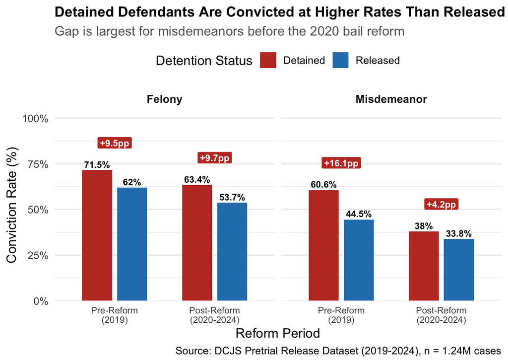

Figure 1: Conviction rate by pretrial detention status and charge type, before vs. after New York’s 2020 bail reform. Detained defendants are convicted at higher rates across every charge type and reform period, with the gap narrowing from 9.5-16.1 percentage points pre-reform to 4.2-9.7 percentage points post-reform. n = 1.24M cases (DCJS Pretrial Release Dataset, 2019-2024).

Detained defendants were convicted at higher rates than released defendants in every group shown. The gap was largest for misdemeanors before the 2020 reform, at 16.1 percentage points, and dropped to 4.2 percentage points afterward, so the reform seems to have meaningfully cut the detention penalty for lower-level charges specifically. For felonies, the gap barely moved (9.5 percentage points pre-reform, 9.7 post-reform), which suggests the reform had less of an effect on more serious cases. This is the first evidence in the project that detention status, separate from charge type, tracks with conviction outcomes.

### Figure 2: County Poverty Rate and the Detention-Conviction Gap

To test whether this gap changes with a county’s economic context, we aggregated case-level data to the county-year level and computed the gap in conviction rates between detained and released defendants for each county and year where ACS poverty data was available (2020-2022). We then fit a weighted linear regression, weighting by each county’s number of detained cases (`n_detained`) so reliable, high-volume counties like Queens count more than small counties where a handful of cases can produce extreme, noisy gap estimates.

```
Call:
lm(formula = gap ~ pct_poverty, data = county_gap_clean, weights = n_detained)

Weighted Residuals:
     Min       1Q   Median       3Q      Max
-1263.26  -341.14  -161.52   -43.59  2340.50

Coefficients:
             Estimate Std. Error t value Pr(>|t|)
(Intercept) 1.009e+01  1.447e+00   6.974 6.63e-11 ***
pct_poverty 1.262e-03  6.333e-04   1.992   0.0479 *
---
Signif. codes:  0 '***' 0.001 '**' 0.01 '*' 0.05 '.' 0.1 ' ' 1

Residual standard error: 438.2 on 169 degrees of freedom
Multiple R-squared:  0.02295,   Adjusted R-squared:  0.01717
F-statistic:  3.97 on 1 and 169 DF,  p-value: 0.04793
```

Why weighting mattered. An earlier, unweighted version of this regression found a small, statistically significant relationship between poverty and the gap (coefficient 0.0014, R-squared 0.025, p = 0.040). Once we weighted by sample size, that relationship held up but didn’t strengthen, coefficient 0.0013, R-squared 0.023, p = 0.048, essentially the same result either way. The weighted model estimates that for every one percentage point increase in a county’s poverty rate, the detention-conviction gap increases by about 0.0013 percentage points. That’s a very small effect in absolute terms, poverty rate alone explains only about 2.3% of the variation in the gap, and the relationship is only marginally significant. We report the weighted version since weighting counties by their detained-case volume is the more defensible methodological choice, but the fact that weighting barely moved the result is itself reassuring: the relationship isn’t an artifact of how small, noisy counties get treated in the model.

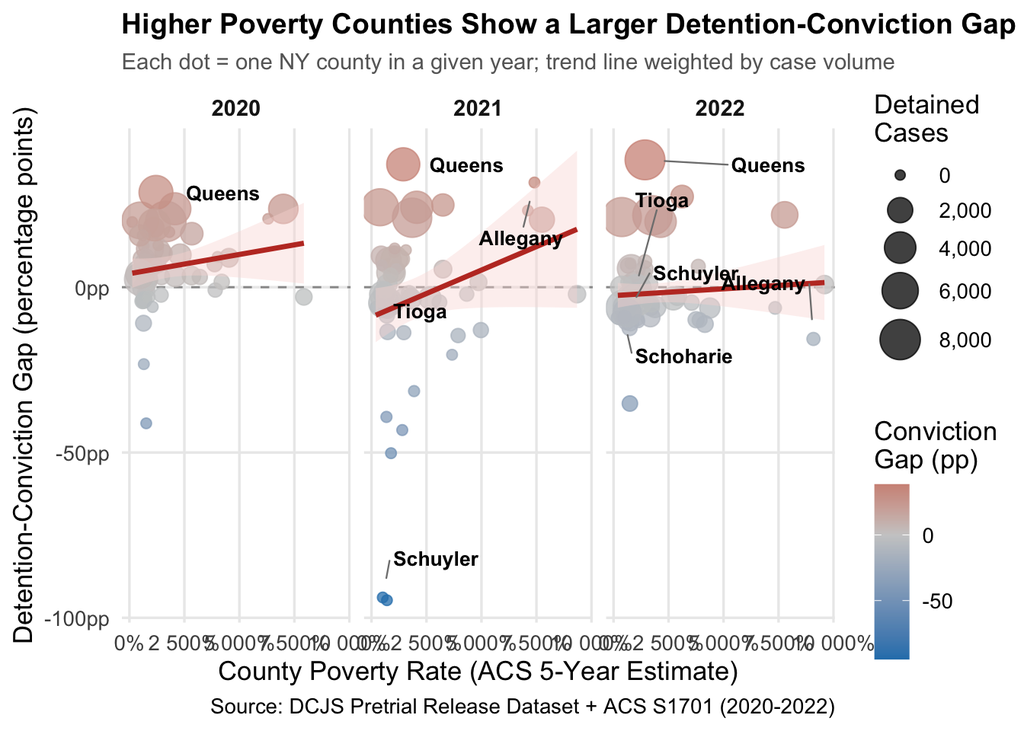

[output not shown]

**Checking for multicollinearity.** Before trusting the logistic regression’s coefficients as individual effect sizes, we checked variance inflation factors (VIF) across the encoded predictor set.

```
                         feature       VIF
6             arr_re_combi_Black  6.528677
7          arr_re_combi_Hispanic  5.524404
9             arr_re_combi_White  5.347226
5  post_reform_Pre-Reform (2019)  1.999705
3                         arr_yr  1.996840
1                       detained  1.120311
4        charge_type_Misdemeanor  1.118035
8   arr_re_combi_Native American  1.095064
2                    pct_poverty  1.009044
```

**Why these two methods.** Logistic regression models a binary outcome directly and produces coefficients that are interpretable as effect sizes through odds ratios, which lets us say something statistically grounded about the size and direction of detention’s effect while holding other variables constant. Random forest complements that because it can pick up nonlinear relationships and interactions between predictors without those interactions being specified ahead of time, and it produces feature importance scores we can compare directly against the logistic regression coefficients, which is the exact comparison our research question needed.

### Logistic Regression Results

```
LogisticRegression(max_iter=1000)
```

```
                         feature  coefficient  odds_ratio
8             arr_re_combi_White     1.001032    2.721087
7   arr_re_combi_Native American     0.687443    1.988623
4  post_reform_Pre-Reform (2019)     0.491118    1.634142
0                       detained     0.378869    1.460631
6          arr_re_combi_Hispanic     0.377142    1.458111
5             arr_re_combi_Black     0.291373    1.338264
1                    pct_poverty     0.000115    1.000115
2                         arr_yr    -0.000265    0.999735
3        charge_type_Misdemeanor    -0.843909    0.430026
```

### Did the Reform Change Detention’s Effect?

Figure 1 shows the detention-conviction gap narrowing after 2020, but that’s a descriptive comparison of percentages, not a statistical test of whether the *relationship* between detention and conviction actually changed. To test that directly, we added a `detained * post_reform` interaction term to the logistic regression.

```
LogisticRegression(max_iter=1000)
```

```
                         feature  coefficient  odds_ratio
0                       detained     0.353020    1.423360
4  post_reform_Pre-Reform (2019)     0.468752    1.597999
9              detained_x_reform     0.140495    1.150844
```

The interaction term came back positive rather than negative (coefficient = 0.14, odds ratio = 1.15), the opposite of what a narrowing detention-conviction relationship would predict. Read at face value, this says the case-level model finds slightly higher odds of conviction for detained defendants after the reform, not lower. That’s in tension with Figure 1’s descriptive gap, which showed the misdemeanor gap shrinking sharply post-reform. One likely explanation is that Figure 1’s improvement is concentrated almost entirely in misdemeanors, while this model pools misdemeanors and felonies together with charge_type as a separate control. If felony cases dominate the case-level sample, a model averaging across both charge types could be masking a charge-specific effect that only shows up once you split misdemeanors and felonies apart, the way Figure 1 does. We haven’t resolved which result to trust more, and that’s a real gap in this analysis, not something we’re brushing past.

### Random Forest Results

```
RandomForestClassifier(n_estimators=200, n_jobs=-1, random_state=42)
```

```
                         feature  importance
1                    pct_poverty    0.548884
3        charge_type_Misdemeanor    0.220083
8             arr_re_combi_White    0.096712
0                       detained    0.052731
2                         arr_yr    0.038981
4  post_reform_Pre-Reform (2019)    0.019196
5             arr_re_combi_Black    0.013320
6          arr_re_combi_Hispanic    0.008722
7   arr_re_combi_Native American    0.001371
```

**Why the two models disagree.** Logistic regression only captures linear, additive relationships between each predictor and the outcome. If poverty’s real relationship with conviction is nonlinear, or depends on interactions with other variables (poverty may matter differently depending on charge type or county context, for example), a random forest can pick that up automatically while logistic regression can’t unless those interactions are built in by hand. Statistical significance, what the logistic regression measures, and predictive importance, what the random forest measures, don’t always point to the same variable, and that disagreement is itself a useful finding here, not just noise to explain away.

### Model Evaluation

We evaluated both models on the held-out test set using AUC-ROC, precision, recall, and F1 score.

```
      Metric  Logistic Regression  Random Forest
0    AUC-ROC             0.663691       0.729938
1  Precision             0.609054       0.643821
2     Recall             0.394629       0.551846
3   F1 Score             0.478936       0.594296
```

The random forest beat logistic regression on every metric. Neither model reaches “excellent” discriminative power (closer to 0.85-0.9 AUC); both land in a “fair” range, meaning conviction outcomes are only partly explained by the case characteristics available here. Things like evidence strength, plea negotiations, or individual judge and prosecutor decisions probably matter too and aren’t captured in this dataset, which is a real limit on how much weight either model’s coefficients or importances should carry as complete explanations.

## Data Ethics

This project relies on data that people didn’t choose to contribute to research. DCJS released the Supplemental Pretrial Release Data File to comply with a statutory reporting mandate from the 2019 reform law, not as an opt-in research resource, so we worked only with de-identified, aggregate- level fields and made no attempt to re-identify anyone.

Several sources of bias are baked into this dataset by construction. Race, ethnicity, and prior-record fields reflect existing disparities in policing and prosecution as much as they reflect individual conduct. A raw comparison of conviction rates by race can’t separate genuine behavioral differences from differential enforcement, charging, or plea-bargaining practices that happen upstream of this data. County poverty figures are ecological measures, they describe a place, not the economic circumstances of any individual defendant in that county, and treating county-level poverty conclusions as statements about individual defendants would be a mistake we’ve tried to avoid throughout.

We also want to be clear about what this analysis doesn’t show. None of the models here prove that detention causes worse outcomes. We haven’t yet controlled for charge severity in detail or prior criminal record, both of which plausibly affect who gets detained in the first place, so some of the association between detention and conviction could just reflect who ends up selected into detention rather than an actual effect of detention itself.

## Conclusions

At the same time, detention isn’t the dominant driver of conviction outcomes once a wider set of predictors is allowed to interact. The random forest, which beat logistic regression on every evaluation metric, found that county poverty rate carries far more predictive weight than detention status, a result the logistic regression’s linear structure couldn’t detect on its own. That the two models disagree matters: relying on just one modeling approach would have led to a different, and incomplete, picture of what actually drives conviction outcomes.

- Confidence and limitations. We’re confident in the directional findings here (detention tracks with higher conviction odds, poverty shows a small positive relationship with the detention-conviction gap) because they hold up across multiple independent approaches. That said, the poverty relationship is weak and only marginally significant (R² = 0.023, p = 0.048), so it should be read as a modest signal rather than a strong finding. The misdemeanor-specific narrowing we see in Figure 1’s group comparison also didn’t hold up the same way in the case-level interaction model, which found a small positive rather than negative interaction between detention and reform, so we’re less confident that reform’s effect on the detention-conviction relationship is as clean as the descriptive figures suggest. We’re less confident about the precision of effect sizes generally, since neither classification model got above an AUC of 0.73, meaning a lot of the variation in conviction outcomes is still unexplained by the variables we have, probably evidence strength, plea negotiation dynamics, and prior criminal history, none of which we’ve fully built in yet.

**Future work.** The clearest next step is adding prior record and a more detailed measure of charge severity to both models, so we can more directly test whether the detention-conviction relationship holds up after controlling for how strong the case against a defendant actually was, the main confound we haven’t ruled out yet. Extending county poverty data past 2020-2022 (limited right now by ACS 5-year estimate availability) would also let us check whether the poverty relationship in Figure 2 holds across the full 2019-2024 window, including the years right before and after the reform.

The core contribution here is bringing together two things prior research looked at separately, pretrial detention’s effect on conviction, and county poverty’s relationship to system involvement, into one New York-specific, reform-aware analysis. County courts, state legislators, and other states weighing similar reforms should take from this that reform effects aren’t uniform. They vary by charge severity, by county economic context, and, in ways this data alone can’t fully explain, by race. Statewide averages hide that variation, and policy built only on statewide averages risks missing where reform is and isn’t actually working.